# sffdr Package Vignette

Andrew J. Bass and Chris Wallace

2026-11-25

## Introduction

The sffdr package implements the surrogate functional false discovery rate (sfFDR) procedure. This methodology integrates GWAS summary statistics from related traits (i.e., pleiotropy) to increase statistical power within the functional FDR framework. The inputs into `sffdr` are a set of p-values from a GWAS of interest and a set of p-values from one or many informative GWAS.

The significance quantities estimated by `sffdr` can be used for a variety of analyses:

- Functional p-value (fp): Controls the type I error rate and can be used for standard significance analyses.
- Functional q-value (fq): A measure of significance in terms of the positive FDR (closely related to FDR).
- Functional local FDR (flfdr): A posterior error probability that is useful for functional fine-mapping and assessing significance of a SNP.

## Citing this package

The methods implemented in this package are described in:

> Bass AJ, Wallace C. Exploiting pleiotropy to enhance variant discovery with functional false discovery rates. [*Nature Computational Science*](https://doi.org/10.1038/s43588-025-00852-3); 2025.

Note that this work is an extension of the functional FDR methodology and the software builds on some of the functions in the `fFDR` package found at https://github.com/StoreyLab/fFDR.

## Getting help

To report any bugs or issues related to usage please report it on GitHub at https://github.com/ajbass/sffdr.

## Installation

You can install the development version of `sffdr` from GitHub:

```r
# install development version of package
install.packages("devtools")
devtools::install_github("ajbass/sffdr")
```

## Quick start guide

To demonstrate the package, we will use a sample dataset containing 10,000 SNPs for body mass index (BMI) as the primary trait of interest, with body fat percentage (BFP), cholesterol, and triglycerides as informative traits.

```r
library(sffdr)
data(bmi)

# Define primary p-values and informative p-values
p <- sumstats$bmi
z <- as.matrix(sumstats[,-1])

head(sumstats)
```

```
#>         bmi      bfp cholesterol triglycerides
#> 1 0.4959680 0.313475   0.0394766      0.148379
#> 2 0.6937320 0.565400   0.8986590      0.298349
#> 3 0.0843257 0.447650   0.7301960      0.715846
#> 4 0.2623540 0.911920   0.1753410      0.775170
#> 5 0.2150660 0.668330   0.0526082      0.603160
#> 6 0.9501450 0.607349   0.2759850      0.867493
```

### 1. Modeling the functional proportion of null tests $\pi_{0}(z)$

The first step is to model the relationship between the functional proportion of null tests and the informative traits. We use `pi0_model` to create a model and `fpi0est` to estimate $\pi_{0}(z)$.

```r
# Create model
mpi0 <- pi0_model(z)
```

```
#> ==================================================
#> Building Pi0 Model (Rank: Signal -> 0.0)
#>   Variables        : 3
#>   Min Discoveries  : 150 (Raw SNPs)
#> --------------------------------------------------
#>   [Auto-Scale]: N = 10,000. Bandwidth set to 200 independent SNPs per knot.
#>   [bfp]: Found 220 discoveries (FDR < 0.25). Calculating knots...
#>   [bfp]: Final Model -> Spline (2 knots: 0.022, 0.1)
#>   [cholesterol]: Fallback -> 1 Knot at 0.1000
#>   [triglycerides]: Found 161 discoveries (FDR < 0.25). Calculating knots...
#>   [triglycerides]: Final Model -> Spline (2 knots: 0.0161, 0.1)
#> --------------------------------------------------
#> ~splines::ns(bfp, knots = c(0.022, 0.1), Boundary.knots = c(0, 1)) + splines::ns(cholesterol, knots = c(0.1), Boundary.knots = c(0, 1)) + splines::ns(triglycerides, knots = c(0.0161, 0.1), Boundary.knots = c(0, 1))
#> ==================================================
```

```r
# Estimation of functional pi0
fpi0 <- fpi0est(p, mpi0)
```

```
#> ==================================================
#> Estimating Functional Pi0
#> ==================================================
#>   Fitting models across 19 lambda values...
#>   Selecting optimal lambda via MISE...
#>   Selected lambda: 0.25
#>   Generating predictions...
#>   Done.
#> ==================================================
#>
```

**Note on Knots**: Ideally, knots should cover the distribution of non-null p-values in your informative studies. Our algorithm uses an FDR threshold to choose the location and number of knots. Depending on the study, you may want to adjust these values (see `?pi0_model`). Note that this toy example contains only 10,000 p-values, so the knot locations are not optimal since the function was designed for GWAS-scale data.

### 2. Estimating the functional significance quantities

With the functional $\pi_{0}$ estimated, we can now calculate the FDR quantities and functional p-values.

```r
# Apply sfFDR
sffdr_out <- sffdr(p, fpi0 = fpi0$fpi0)
```

```
#> ==================================================
#> Running sfFDR Analysis (v1.2.5)
#> ==================================================
#>   Transforming surrogate variable...
#>   Fitting kernel density...
#>     High-Res Tcub (nn=0.05, h=0.10772)... ✓
#>   Enforcing conditional monotonicity using the 'min' method...
#>     Dividing data into 10 conditional surrogate bins...
#>   Computing functional local FDRs...
#>   Computing functional p-values and q-values...
#>   Done.
#> ==================================================
```

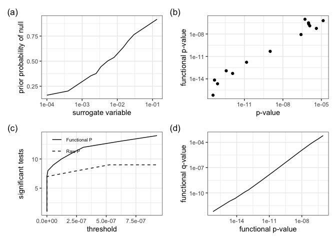

```r
# Extract results
results <- data.frame(
  p_value = p,
  fp_value = sffdr_out$fpvalues,
  fq_value = sffdr_out$fqvalues,
  flfdr = sffdr_out$flfdr
)

# Plot significance results (focusing on high-significance SNPs)
plot(sffdr_out, rng = c(0, 1e-6))
```

### 3. Incorporating linkage disequilibrium (LD)

In standard GWAS, SNPs are often correlated due to LD. To account for this, you should provide a vector indicating which SNPs are LD-independent (e.g., via pruning). `sffdr` uses these independent SNPs to fit the model, then computes the significance quantities for the entire dataset.

For GWAS, we recommend cross-fitting by chromosome (Liley and Wallace, 2021). To do this, provide the chromosome labels in `folds`: each SNP is then evaluated using a fit that excludes its chromosome, i.e., leave-one-chromosome-out (LOCO). The `nfolds` argument groups the chromosomes into fewer folds (e.g., `nfolds = 5`) to reduce computation time, and `ncores` runs the folds in parallel.

```r
# Fit model using LD-independent subset (indep_snps: TRUE if SNP is LD-independent)
mpi0 <- pi0_model(z = z, indep_snps = indep_snps)
fpi0 <- fpi0est(p, mpi0, indep_snps = indep_snps)

# Recommended: cross-fit by chromosome (chr: the chromosome of each SNP)
sffdr_out <- sffdr(p, fpi0 = fpi0$fpi0, folds = chr, nfolds = 5)

# Without LD-independent SNPs (slower): pi0 is estimated in the same folds
fpi0 <- fpi0est(p, pi0_model(z = z), folds = chr, nfolds = 5)
sffdr_out <- sffdr(p, fpi0 = fpi0$fpi0, folds = chr, nfolds = 5)
```

**Note on `folds`**: `sffdr()` without `folds` (as in the quick start) is superseded by cross-fitting by chromosome, which has better tail behavior under LD.

**Note on computational time**: On a single core, LOCO takes about 1 minute for 1 million SNPs and 7 minutes for 10 million. We recommend `nfolds = 5`: in our simulations five folds provided the same power as LOCO at genome-wide significance in a third of the time. For low-powered studies, LOCO (the default) keeps more power in the functional q-values.

**Note on choosing independent SNPs**: There are two strategies: (1) prune using plink (e.g., `--indep-pairwise 200kb 1 0.3`) and use the pruned set of SNPs as the independent set, or (2) use informed sampling using the informative traits (e.g., clumping or selecting a representative SNP in an LD block with the smallest informative p-value). The latter is likely better when the primary study has low power.

## Advanced usage

### Incorporating LD scores

If LD scores ($l_{j}$) are available (e.g., from LDSC regression), there are two ways to use them.

1. **As a covariate** in the functional $\pi_{0}$ model:

```r
# LD score (log scale) added to the pi0 model built by pi0_model()
zt <- cbind(mpi0$zt, ld = log(ld_score))
fmod <- update(mpi0$fmod, ~ . + ns(ld, df = 3))
fpi0 <- fpi0est(p, z = zt, pi0_model = fmod, indep_snps = indep_snps)
sffdr_out <- sffdr(p, fpi0 = fpi0$fpi0, folds = chr, nfolds = 5)
```

2. **As inverse weights in the $\pi_{0}$ fit** ($w_j = 1/l_{j}$), in place of LD pruning:

```r
w <- 1 / ld_score
mpi0 <- pi0_model(z, weights = w)
fpi0 <- fpi0est(p, mpi0, weights = w)
sffdr_out <- sffdr(p, fpi0 = fpi0$fpi0, folds = chr, nfolds = 5)
```

**Note on incorporating LD scores**: As LD scores are available for common reference panels (e.g., 1000 Genomes), they can be easily downloaded to use in sfFDR. If you have LD scores calculated from your data then that’s even better. However, it is problematic to use LD scores when the reference panel is not matched to your study population. In that case, the pruning (or informative sampling) strategy discussed above is the best option.

### Sample overlap with the informative studies

If the primary and informative studies share participants (e.g., traits measured in the same biobank), decorrelate the informative studies with `decorrelate_informative()` and use its p-values (`$p2`) in `pi0_model()`. The primary p-values are used unchanged (see `?decorrelate_informative`).

### Expected $\chi^{2}$ from annotations

When the informative variable is the expected $\chi^{2}$ given functional annotations (Bass et al. 2026), use `pi0_model_echisq()` in place of `pi0_model()` (see `?pi0_model_echisq`):

```r
mpi0 <- pi0_model_echisq(echisq, indep_snps = indep_snps)
fpi0 <- fpi0est(p, mpi0, indep_snps = indep_snps)
sffdr_out <- sffdr(p, fpi0 = fpi0$fpi0, surrogate = echisq, folds = chr, nfolds = 5)
```

Other annotations (e.g., the LD score or MAF) can be included as further columns:

```r
mpi0 <- pi0_model_echisq(cbind(echisq = echisq, ld = ld_score), indep_snps = indep_snps)
fpi0 <- fpi0est(p, mpi0, indep_snps = indep_snps)
sffdr_out <- sffdr(p, fpi0 = fpi0$fpi0, folds = chr, nfolds = 5)
```

### Manual Knot Selection and using other informative variables

The selection of knots in the B-spline basis is an important tuning parameter in sffdr. If your surrogate GWAS has extremely high power (very small p-values), we recommend placing more knots at the lower end of the p-value distribution to capture the local density of signals.

```r
# Create model (can include other variables (e.g., MAF) or specify more complicated models)
fmod <- "~ns(bfp, knots = c(0.01, 0.025, 0.05, 0.1))"
fpi0_mod <- fpi0est(p = p,
                    z = mpi0$zt,
                    pi0_model = fmod)
```

**Note on incorporating additional variables**: Other informative covariates can be included in the model (e.g., MAF, LD score, etc.). While the LD score annotations can be used (e.g., the baselineLD model), we have found that using the expected $\chi^{2}$ given the annotations performs better in practice and simplifies the model fitting.